# Giro Velogames Daily Update

### Race Results - Stage 20

Here’s the non-spoiler 5min highlight clip on Youtube:  
https://youtu.be/hDzCWYsX_zM  
A select group of GC contenders made the expected break on the final climb of last night’s Stage 20 battle. Thibaut Pinot claimed his first Giro victory, taking the sprint ahead of Ilnur Zakarin and Nibali. Although Tom Dumoulin trailed this group and Pinot replaced the Dutchman in third position overall, Dumoulin sits only 53 seconds behind race leader Quintana. Not enough of a buffer for any of the riders holding the top three spots is the opinion of most top cycling analysts with Big Tom expected to gain at least as much as this in tonight’s final stage Individual Time Trial.  
Results on cycling news:  
http://www.cyclingnews.com/giro-ditalia/stage-20/results/

| Stage Result |
| --- |

|  | # | Rider Name (Country) Team | Result |
| --- | --- | --- | --- |
| 2 | 1 | Thibaut Pinot (Fra) FDJ | 4:57:58 |
| 3 | 2 | Ilnur Zakarin (Rus) Katusha-Alpecin |  |
| 4 | 3 | Vincenzo Nibali (Ita) Bahrain-Merida |  |
| 5 | 4 | Domenico Pozzovivo (Ita) AG2R La Mondiale |  |
| 6 | 5 | Nairo Quintana (Col) Movistar Team |  |
| 7 | 6 | Bob Jungels (Lux) Quick-Step Floors | 0:00:15 |
| 8 | 7 | Adam Yates (GBr) Orica-Scott |  |
| 9 | 8 | Sébastien Reichenbach (Swi) FDJ |  |
| 10 | 9 | Bauke Mollema (Ned) Trek-Segafredo |  |
| 11 | 10 | Tom Dumoulin (Ned) Team Sunweb |  |

| General Classification |
| --- |

|  | # | Rider Name (Country) Team | Result |
| --- | --- | --- | --- |
| 2 | 1 | Nairo Quintana (Col) Movistar Team | 90:00:38 |
| 3 | 2 | Vincenzo Nibali (Ita) Bahrain-Merida | 0:00:39 |
| 4 | 3 | Thibaut Pinot (Fra) FDJ | 0:00:43 |
| 5 | 4 | Tom Dumoulin (Ned) Team Sunweb | 0:00:53 |
| 6 | 5 | Ilnur Zakarin (Rus) Katusha-Alpecin | 0:01:15 |
| 7 | 6 | Domenico Pozzovivo (Ita) AG2R La Mondiale | 0:01:30 |
| 8 | 7 | Bauke Mollema (Ned) Trek-Segafredo | 0:03:03 |
| 9 | 8 | Adam Yates (GBr) Orica-Scott | 0:06:50 |
| 10 | 9 | Bob Jungels (Lux) Quick-Step Floors | 0:07:18 |
| 11 | 10 | Davide Formolo (Ita) Cannondale-Drapac | 0:12:55 |

| Points classification |
| --- |

|  | # | Rider Name (Country) Team | Result |
| --- | --- | --- | --- |
| 2 | 1 | Fernando Gaviria (Col) Quick-Step Floors | 325 |
| 3 | 2 | Jasper Stuyven (Bel) Trek-Segafredo | 192 |
| 4 | 3 | Sam Bennett (Irl) Bora-Hansgrohe | 117 |
| 5 | 4 | Daniel Teklehaimanot (Eri) Dimension Data | 100 |
| 6 | 5 | Lukas Pöstlberger (Aut) Bora-Hansgrohe | 98 |
| 7 | 6 | Pavel Brutt (Rus) Gazprom – Rusvelo | 76 |
| 8 | 7 | Kristian Sbaragli (Ita) Dimension Data | 76 |
| 9 | 8 | Eugert Zhupa (Alb) Wilier Triestina | 70 |
| 10 | 9 | Roberto Ferrari (Ita) UAE Team Emirates | 70 |
| 11 | 10 | Tom Dumoulin (Ned) Team Sunweb | 68 |

### Velogames Results - Brissy Boys - Stage 20

#### Highest Scoring Riders

##### for the stage, from our teams

The riders earning maximum points for Stage 20, and the teams that picked them were:

| rider | stage | Total | Selected by |
| --- | --- | --- | --- |
| Thibaut Pinot | 20 | 178 | US Postal Service Circa 1999-2005 |
| Ilnur Zakarin | 20 | 147 | Ferris Wheel,White Rose |
| Vincenzo Nibali | 20 | 126 | The Last Minute Brigade |
| Domenico Pozzovivo | 20 | 124 | Brake Rub Regression |
| Nairo Quintana | 20 | 116 | Itchy Nads,Dick`s Dodgers,Brake Rub Regression,Ferris Wheel,The Last Minute Brigade,US Postal Service Circa 1999-2005 |
| Bob Jungels | 20 | 82 | Itchy Nads |
| Adam Yates | 20 | 73 | Dick`s Dodgers,Brake Rub Regression |
| Sebastien Reichenbach | 20 | 66 | The Last Minute Brigade |
| Bauke Mollema | 20 | 54 | Ferris Wheel,White Rose |
| Omar Fraile | 20 | 19 | Itchy Nads |

Another take on rider data is provided in the chart below displaying Rider Cost vs the their Total Points accrued so far. The size of each circle is proportional the the number of teams that have selected that rider.

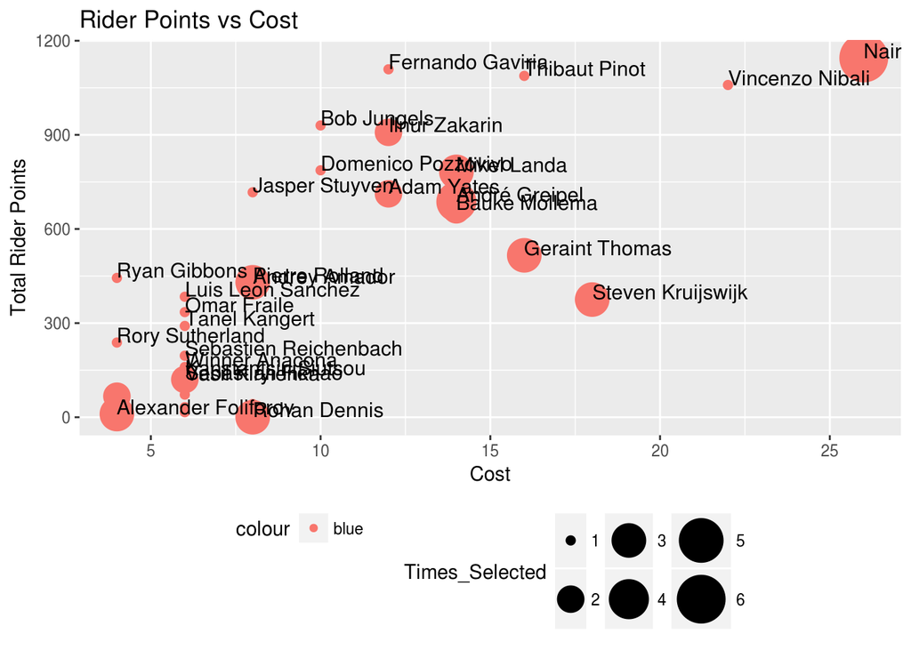

#### Top scoring teams for stage

So Simon Lyons cleaned up stage 20.

| team | directeur | Stage_Points |
| --- | --- | --- |
| Brake Rub Regression | Simon Lyons | 331 |
| Ferris Wheel | Jeff Beehler | 319 |
| The Last Minute Brigade | Andrew Johnston | 308 |
| US Postal Service Circa 1999-2005 | Mick Cole | 307 |
| White Rose | James Johnston | 246 |
| Itchy Nads | Dan | 242 |
| Dick`s Dodgers | Rich | 197 |

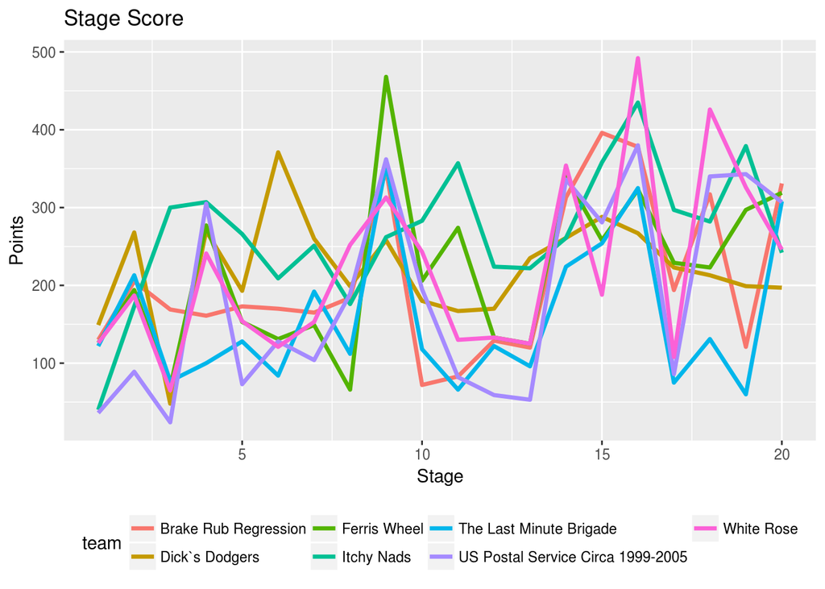

The picture for overall after 20 stages is:

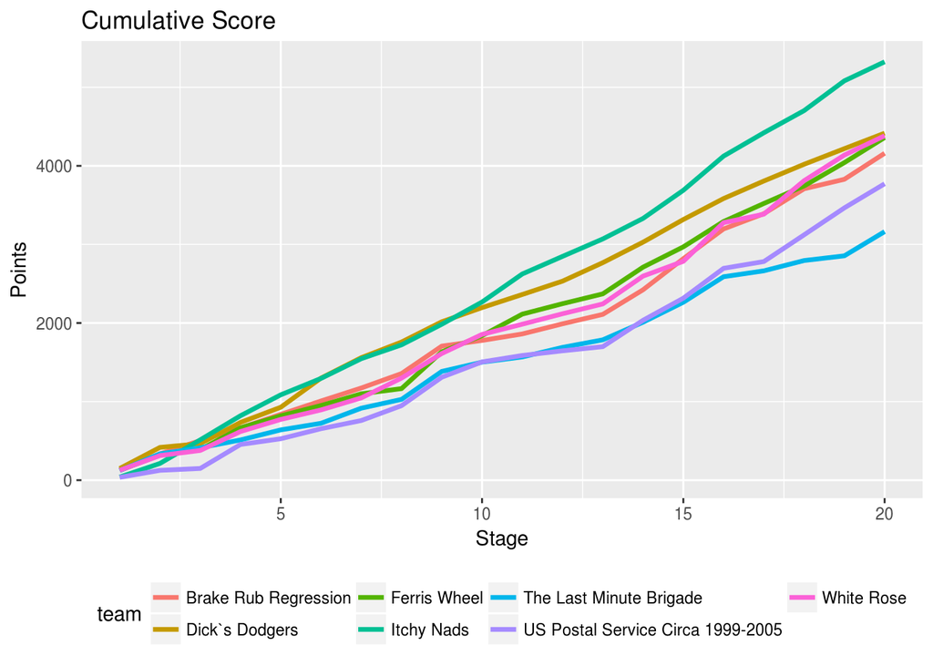

| Team | Total |
| --- | --- |
| Itchy Nads | 5324 |
| Dick`s Dodgers | 4416 |
| White Rose | 4383 |
| Ferris Wheel | 4360 |
| Brake Rub Regression | 4160 |
| US Postal Service Circa 1999-2005 | 3772 |
| The Last Minute Brigade | 3163 |

#### Inside Look

Here’s a look inside the teams currently holding top spots on the GC podium.

Rider Scores - Top Teams

| Team | Rider | Rider Total |
| --- | --- | --- |
| Dick`s Dodgers | Nairo Quintana | 1145 |
| Dick`s Dodgers | Jasper Stuyven | 717 |
| Dick`s Dodgers | Adam Yates | 712 |
| Itchy Nads | Nairo Quintana | 1145 |
| Itchy Nads | Fernando Gaviria | 1109 |
| Itchy Nads | Bob Jungels | 930 |
| White Rose | Ilnur Zakarin | 908 |
| White Rose | Mikel Landa | 782 |
| White Rose | André Greipel | 687 |

Next up is Stage 21.  
http://www.cyclingnews.com/giro-ditalia/stage-21/

### Team Cross Reference

Here’s a more useful version of the table I sent out with the Stage 1 update. As well as identifying which riders have been selected the most times in our Velogames squads, it now includes which teams have each rider. It should be helpful in determining which of your squad are essentially a null contribution given they are matched in one or more other teams.

| rider | Times_Selected | Andrew Johnston | Dan | James Johnston | Jeff Beehler | Mick Cole | Rich | Simon Lyons |
| --- | --- | --- | --- | --- | --- | --- | --- | --- |
| Nairo Quintana | 6 | Yes | Yes |  | Yes | Yes | Yes | Yes |
| André Greipel | 4 | Yes |  | Yes | Yes |  |  | Yes |
| Alexander Foliforov | 3 |  | Yes |  |  |  | Yes | Yes |
| Geraint Thomas | 3 |  | Yes |  |  | Yes | Yes |  |
| Mikel Landa | 3 |  | Yes | Yes |  | Yes |  |  |
| Pierre Rolland | 3 |  | Yes |  | Yes |  | Yes |  |
| Rohan Dennis | 3 | Yes |  | Yes | Yes |  |  |  |
| Steven Kruijswijk | 3 |  |  | Yes |  |  | Yes | Yes |
| Adam Yates | 2 |  |  |  |  |  | Yes | Yes |
| Bauke Mollema | 2 |  |  | Yes | Yes |  |  |  |
| Ilnur Zakarin | 2 |  |  | Yes | Yes |  |  |  |
| Michal Schlegel | 2 | Yes |  |  |  | Yes |  |  |
| Philip Deignan | 2 |  | Yes |  |  |  | Yes |  |
| Sebastián Henao | 2 |  |  |  | Yes | Yes |  |  |
| Andrey Amador | 1 |  |  | Yes |  |  |  |  |
| Andrey Zeits | 1 | Yes |  |  |  |  |  |  |
| Bob Jungels | 1 |  | Yes |  |  |  |  |  |
| Carlos Verona | 1 |  |  |  |  | Yes |  |  |
| Dmitry Kozonchuk | 1 | Yes |  |  |  |  |  |  |
| Domenico Pozzovivo | 1 |  |  |  |  |  |  | Yes |
| Fernando Gaviria | 1 |  | Yes |  |  |  |  |  |
| Georg Preidler | 1 |  |  |  |  |  |  | Yes |
| Jasper Stuyven | 1 |  |  |  |  |  | Yes |  |
| Kanstantsin Siutsou | 1 |  |  |  |  |  |  | Yes |
| Luis Leon Sanchez | 1 |  |  | Yes |  |  |  |  |
| Matteo Pelucchi | 1 |  |  |  |  | Yes |  |  |
| Michael Hepburn | 1 |  |  |  |  | Yes |  |  |
| Omar Fraile | 1 |  | Yes |  |  |  |  |  |
| Rory Sutherland | 1 |  |  |  |  |  |  | Yes |
| Ryan Gibbons | 1 |  |  |  |  |  | Yes |  |
| Sebastien Reichenbach | 1 | Yes |  |  |  |  |  |  |
| Sergey Firsanov | 1 | Yes |  |  |  |  |  |  |
| Tanel Kangert | 1 |  |  |  | Yes |  |  |  |
| Thibaut Pinot | 1 |  |  |  |  | Yes |  |  |
| Vasil Kiryienka | 1 |  |  |  | Yes |  |  |  |
| Vincenzo Nibali | 1 | Yes |  |  |  |  |  |  |
| Winner Anacona | 1 |  |  | Yes |  |  |  |  |